# DengAI

### GRAPH: Total_cases by climate variables (both cities together)

Scatterplot using training set only.

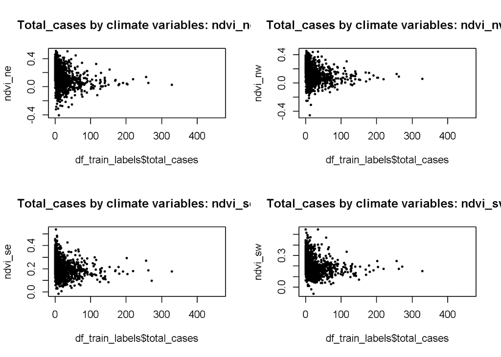

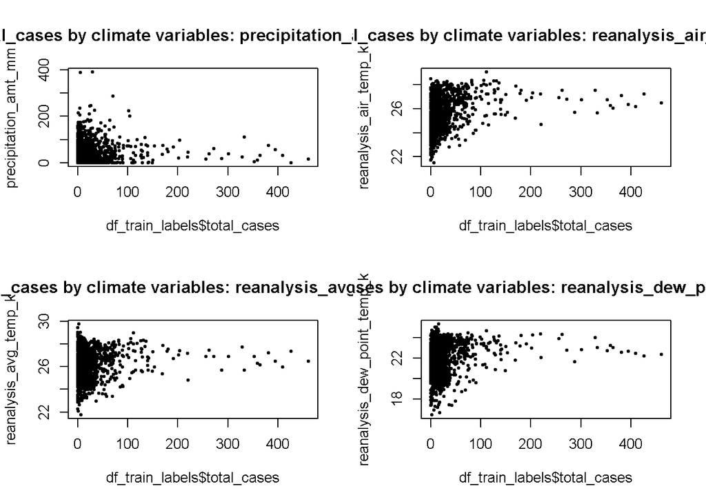

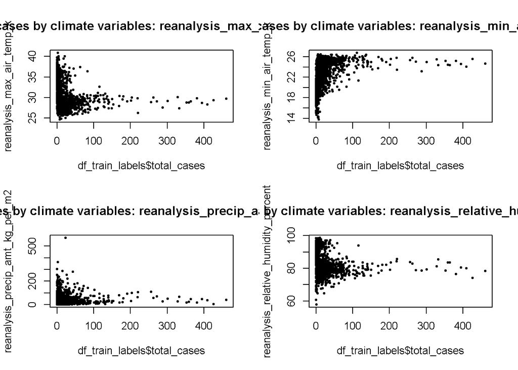

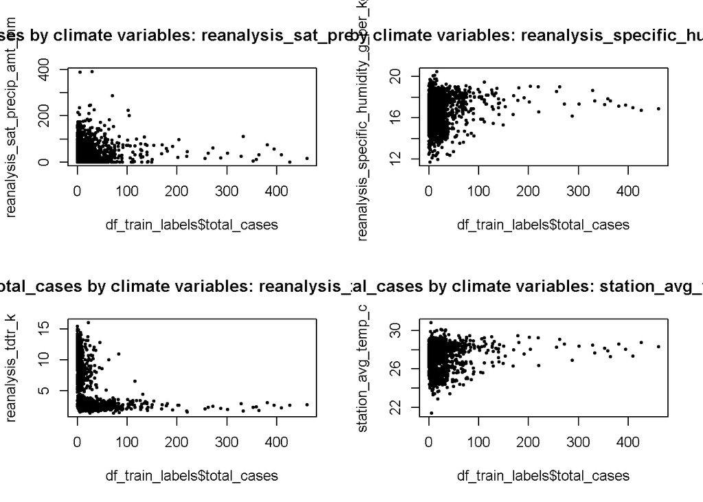

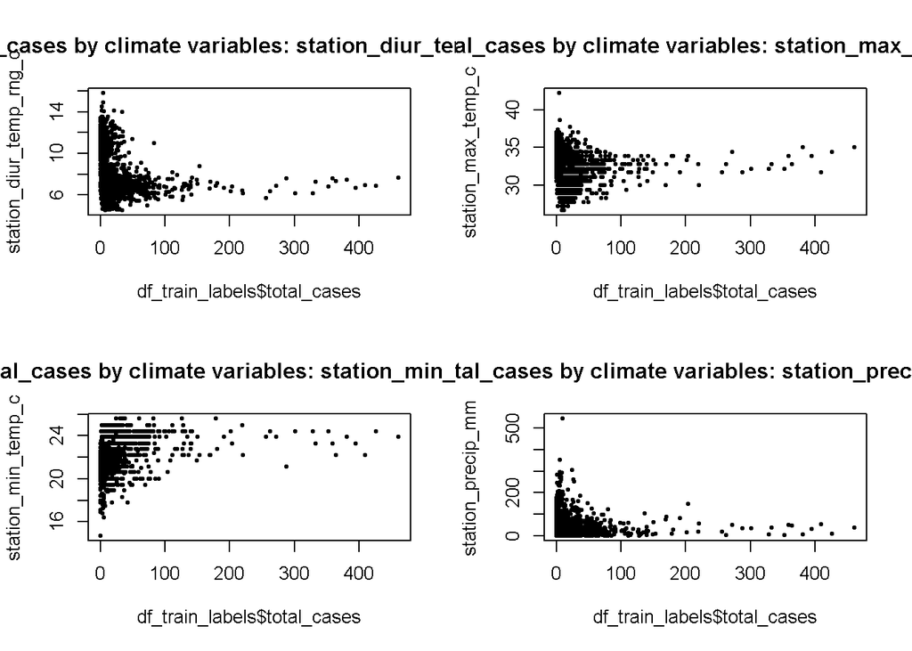

```r
cnames <- colnames(df_train_labels)
par(mfrow=c(2,2))
for (i in 5:(ncol(df_train_labels)-1)) {
 plot(df_train_labels$total_cases,
      df_train_labels[,i],
      cex = 0.5,
      pch = 19,
      ylim = c(min(df_train_labels[,i],na.rm=TRUE), max(df_train_labels[,i],na.rm=TRUE)),
      main = paste("Total_cases by climate variables", cnames[i], sep = ": "),
      ylab = cnames[i])

}
```

### GRAPH: Total_cases by climate variables for **SJ**

Same as above but for SJ

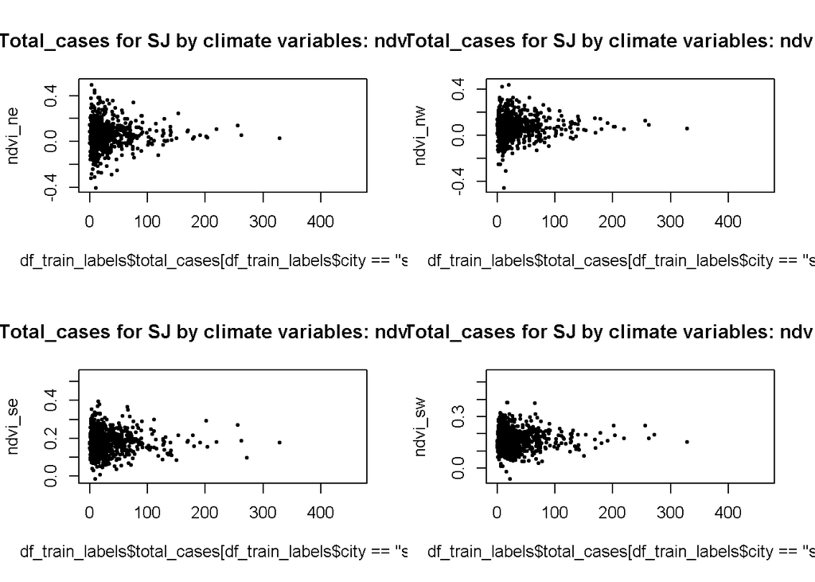

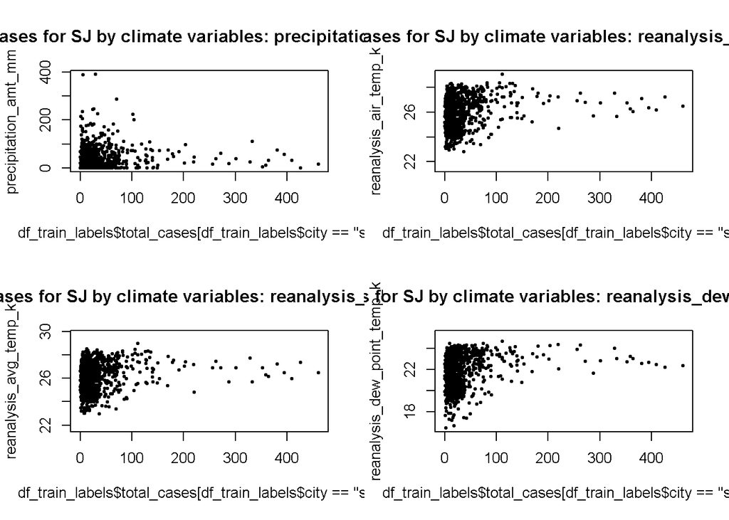

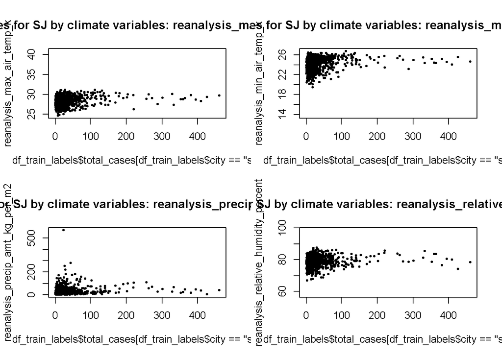

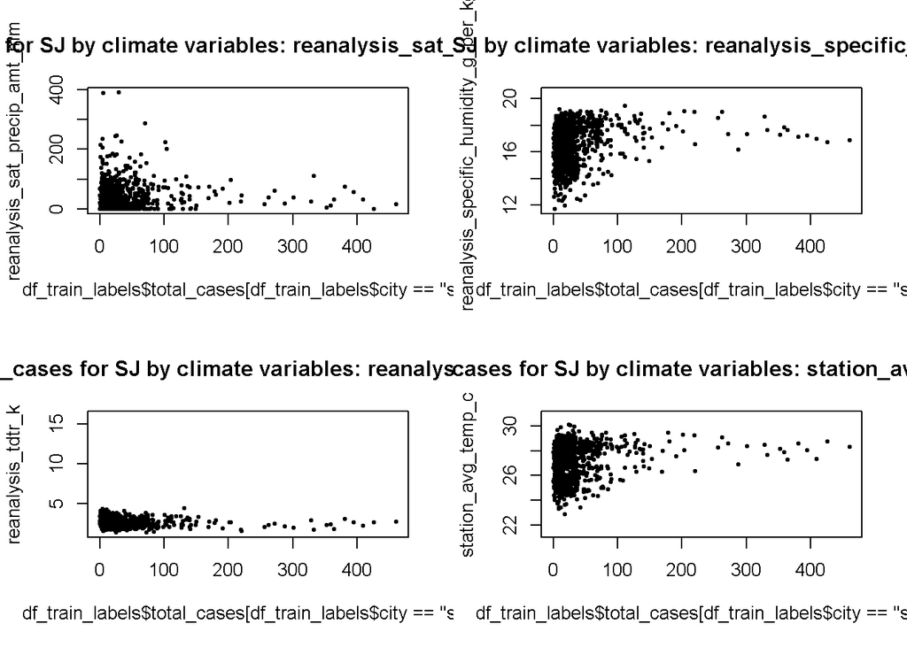

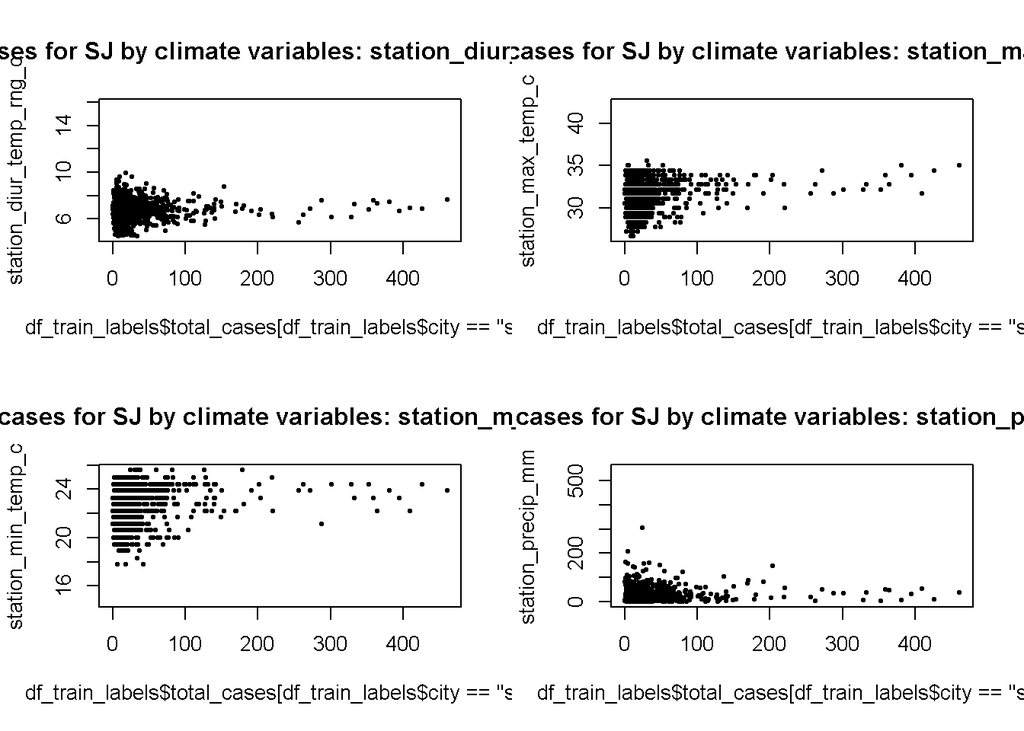

```r
cnames <- colnames(df_train_labels)
par(mfrow=c(2,2))
for (i in 5:(ncol(df_train_labels)-1)) {
 plot(df_train_labels$total_cases[df_train_labels$city == "sj"],
      df_train_labels[df_train_labels$city == "sj",i],
      cex = 0.5,
      pch = 19,
      ylim = c(min(df_train_labels[,i],na.rm=TRUE), max(df_train_labels[,i],na.rm=TRUE)),
      main = paste("Total_cases for SJ by climate variables", cnames[i], sep = ": "),
      ylab = cnames[i])

}
```

### GRAPH: Total_cases by climate variables for **IQ**

Same as above but for IQ.

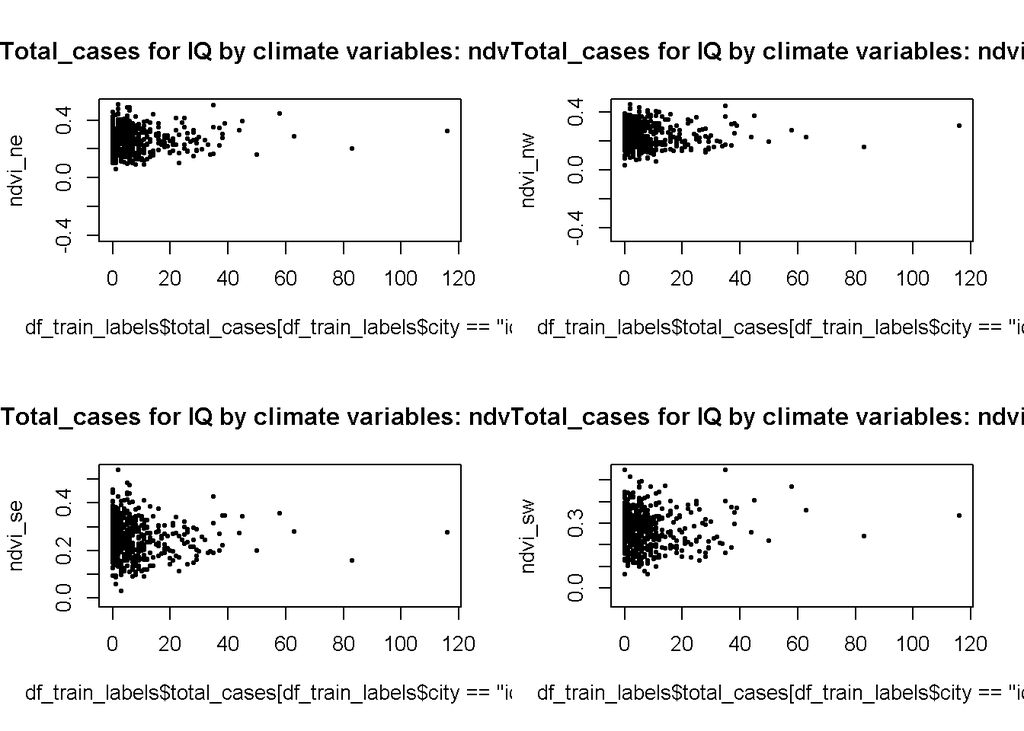

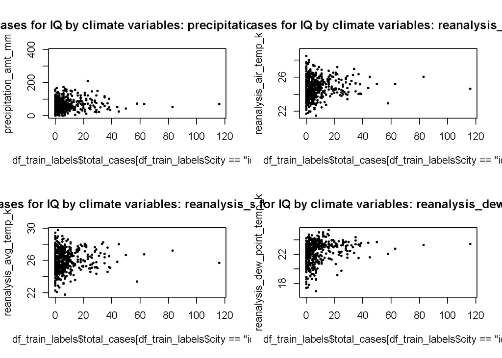

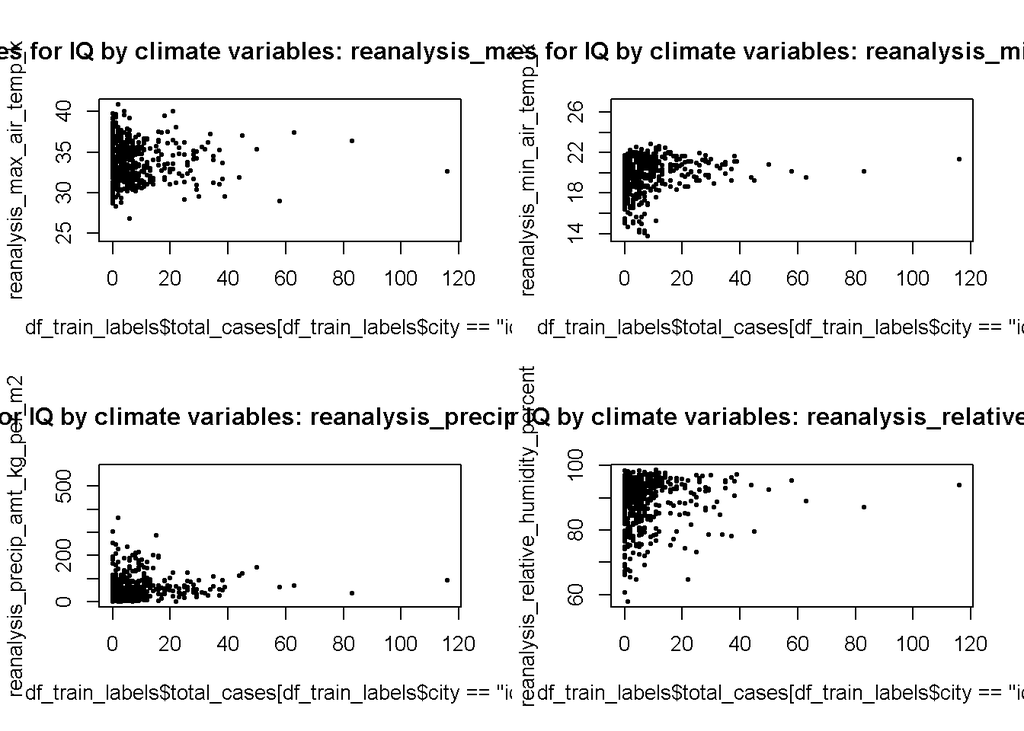

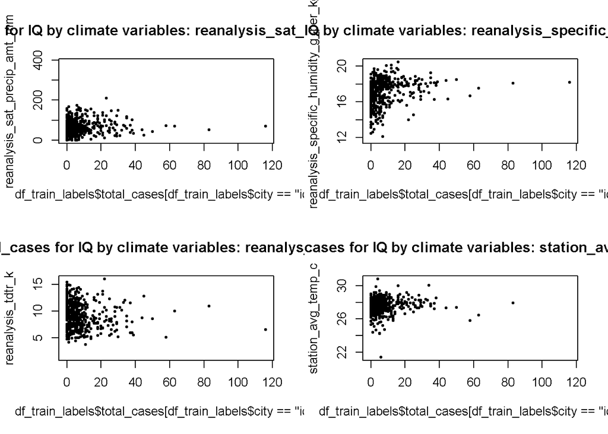

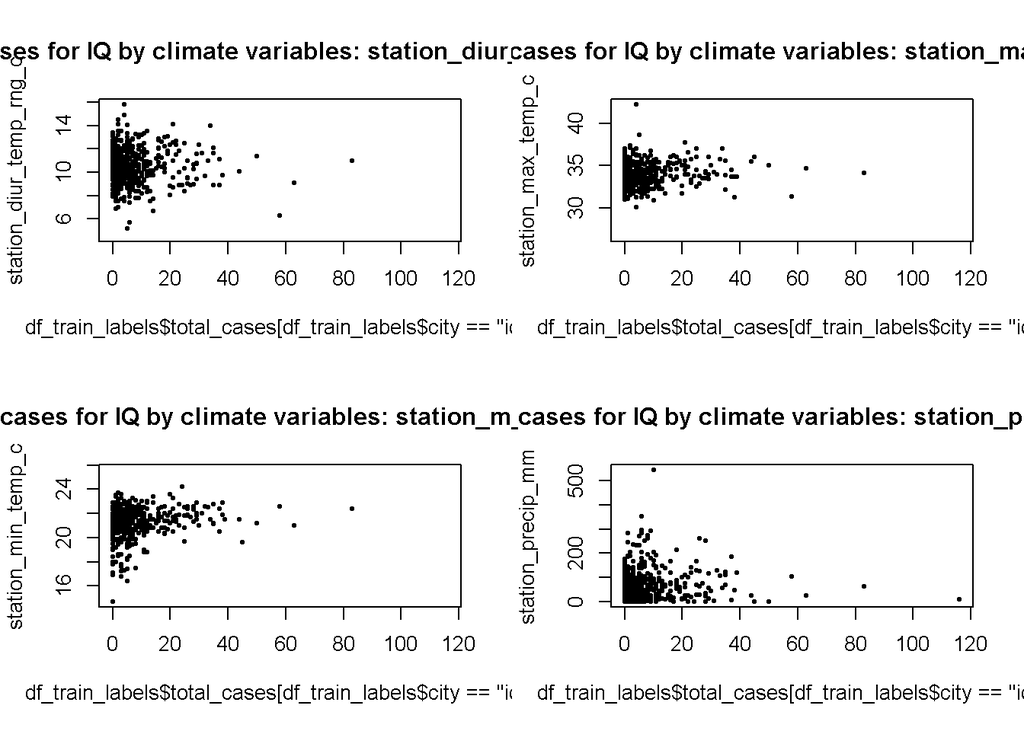

```r
cnames <- colnames(df_train_labels)
par(mfrow=c(2,2))
for (i in 5:(ncol(df_train_labels)-1)) {
 plot(df_train_labels$total_cases[df_train_labels$city == "iq"],
      df_train_labels[df_train_labels$city == "iq",i],
      cex = 0.5,
      pch = 19,
      ylim = c(min(df_train_labels[,i],na.rm=TRUE), max(df_train_labels[,i],na.rm=TRUE)),
      main = paste("Total_cases for IQ by climate variables", cnames[i], sep = ": "),
      ylab = cnames[i])

}
```

## Compare the means between same variables in different cities

We can see that the same feature is significantly different in each city

```r
cnames <- colnames(sj_train_labels)
for (i in 5:(ncol(sj_train_labels))){
  wilt <- wilcox.test(sj_train_labels[,i],iq_train_labels[,i])
  print(cnames[i])
  print(wilt)
}
```

```
## [1] "ndvi_ne"
##
##  Wilcoxon rank sum test with continuity correction
##
## data:  sj_train_labels[, i] and iq_train_labels[, i]
## W = 21691, p-value < 2.2e-16
## alternative hypothesis: true location shift is not equal to 0
##
## [1] "ndvi_nw"
##
##  Wilcoxon rank sum test with continuity correction
##
## data:  sj_train_labels[, i] and iq_train_labels[, i]
## W = 32596, p-value < 2.2e-16
## alternative hypothesis: true location shift is not equal to 0
##
## [1] "ndvi_se"
##
##  Wilcoxon rank sum test with continuity correction
##
## data:  sj_train_labels[, i] and iq_train_labels[, i]
## W = 107990, p-value < 2.2e-16
## alternative hypothesis: true location shift is not equal to 0
##
## [1] "ndvi_sw"
##
##  Wilcoxon rank sum test with continuity correction
##
## data:  sj_train_labels[, i] and iq_train_labels[, i]
## W = 78560, p-value < 2.2e-16
## alternative hypothesis: true location shift is not equal to 0
##
## [1] "precipitation_amt_mm"
##
##  Wilcoxon rank sum test with continuity correction
##
## data:  sj_train_labels[, i] and iq_train_labels[, i]
## W = 118470, p-value < 2.2e-16
## alternative hypothesis: true location shift is not equal to 0
##
```

[output cut: 112 more lines]

```
## [1] "station_precip_mm"
##
##  Wilcoxon rank sum test with continuity correction
##
## data:  sj_train_labels[, i] and iq_train_labels[, i]
## W = 142000, p-value < 2.2e-16
## alternative hypothesis: true location shift is not equal to 0
##
## [1] "total_cases"
##
##  Wilcoxon rank sum test with continuity correction
##
## data:  sj_train_labels[, i] and iq_train_labels[, i]
## W = 401310, p-value < 2.2e-16
## alternative hypothesis: true location shift is not equal to 0
```

## Compare similar variable values within the dataset

There are several variables which appear to be the same feature but taken from a different source. For example, station_precip_mm and precipitation_amt_mm and reanalysis_sat_precip_amt_mm all appear to be the same “Total Precipitation value” Only one should be kept if they are the same.

### Difference in max air temp

“station_max_temp_c”" and “reanalysis_max_air_temp_k” (scaled to Celcius)

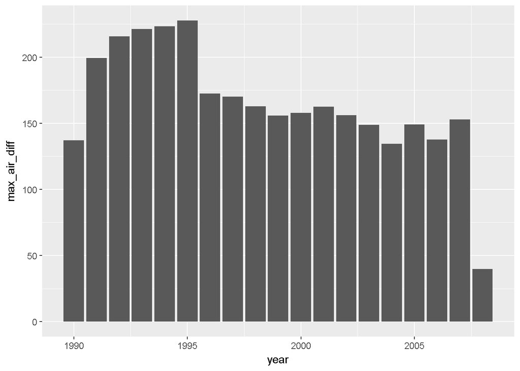

```r
library(ggplot2)

#generate a difference in max temp variable
sj_train_labels$max_air_diff <- sj_train_labels$station_max_temp_c - sj_train_labels$reanalysis_max_air_temp_k

#barplot the difference by year
ggplot(sj_train_labels,aes(x=year, y=max_air_diff))+
  geom_bar(stat='identity')
```

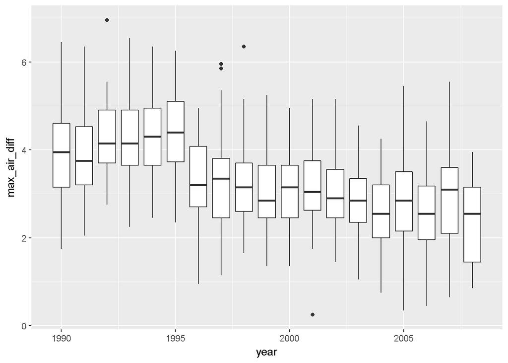

```r
#box plot difference by year
ggplot(sj_train_labels, aes(x=year, y = max_air_diff, group = year)) +   geom_boxplot()
```

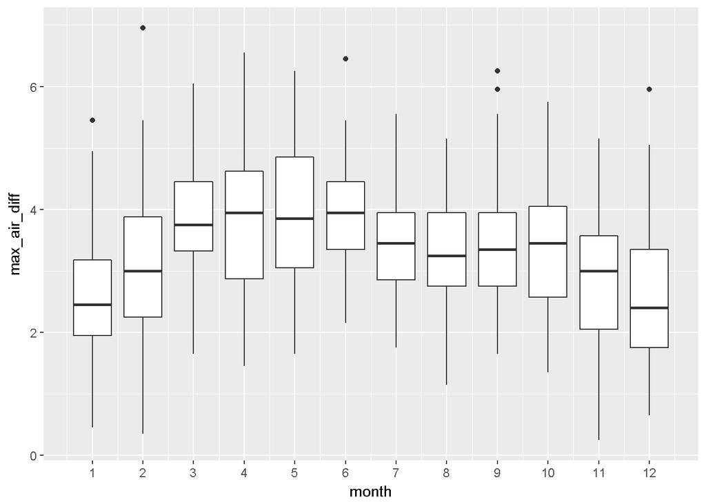

```r
#Add month to the dataframe
sj_train_labels$month <- as.POSIXlt(sj_train_labels$week_start_date)$mon +1

#box plot difference by month
ggplot(sj_train_labels, aes(x=month, y = max_air_diff, group = month)) +   geom_boxplot() + scale_x_continuous(breaks=seq(1,12,1))
```

```r
sj_train_labels$max_air_diff <- NULL
sj_train_labels$month <- NULL
```

### Difference in min air temp

“station_min_temp_c”" and “reanalysis_min_air_temp_k” (scaled to Celcius)

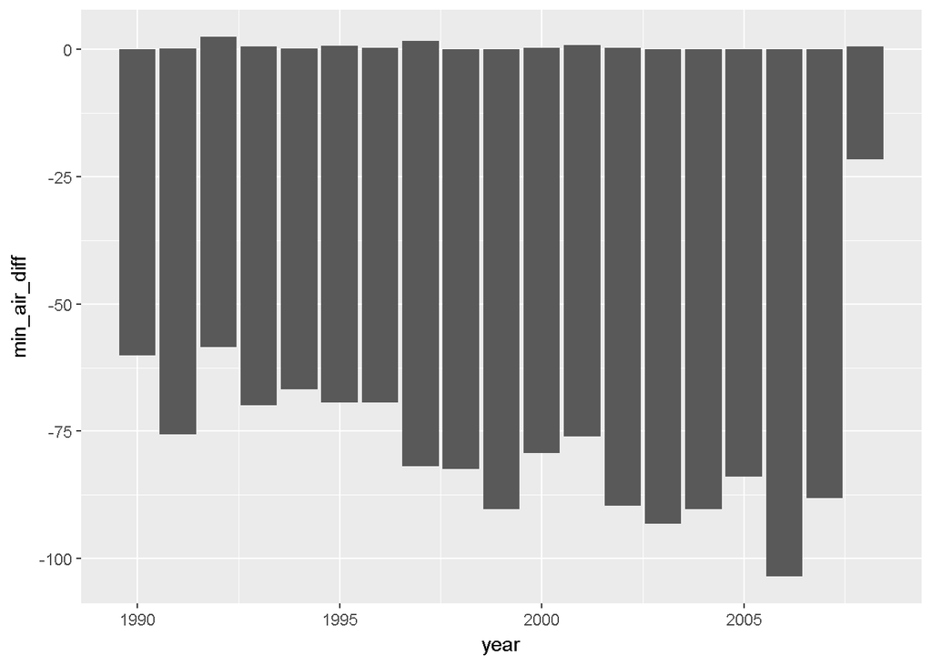

```r
library(ggplot2)

#generate a difference in max temp variable
sj_train_labels$min_air_diff <- sj_train_labels$station_min_temp_c - sj_train_labels$reanalysis_min_air_temp_k

#barplot the difference by year
ggplot(sj_train_labels,aes(x=year, y=min_air_diff))+
  geom_bar(stat='identity')
```

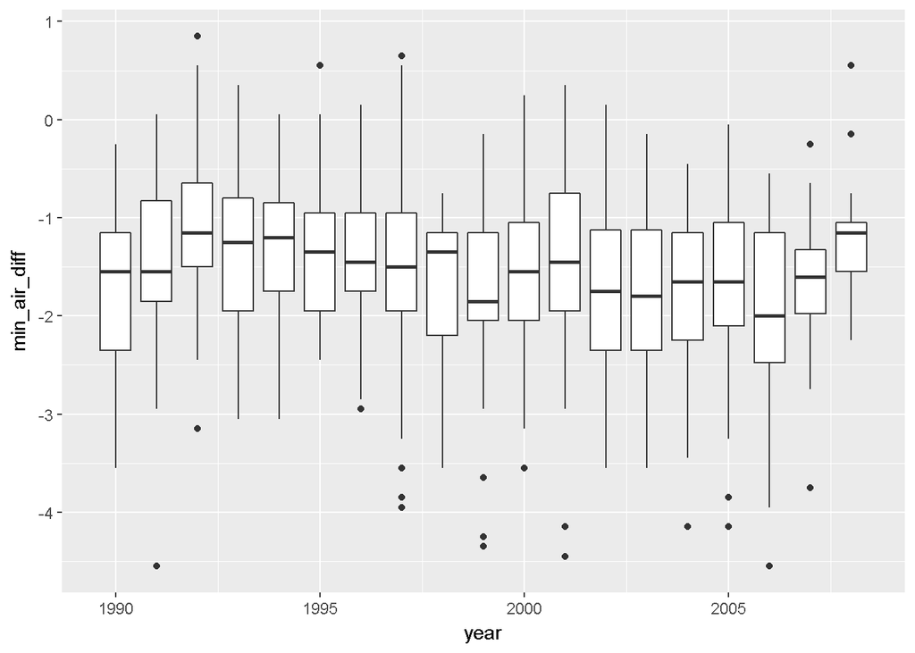

```r
#box plot difference by year
ggplot(sj_train_labels, aes(x=year, y = min_air_diff, group = year)) +   geom_boxplot()
```

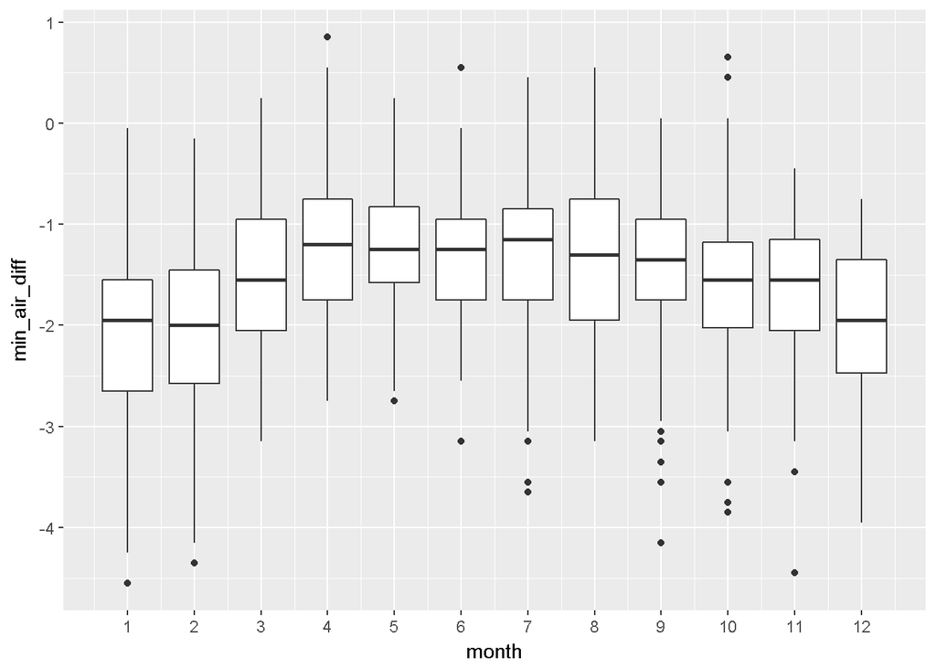

```r
#Add month to the dataframe
sj_train_labels$month <- as.POSIXlt(sj_train_labels$week_start_date)$mon +1

#box plot difference by month
ggplot(sj_train_labels, aes(x=month, y = min_air_diff, group = month)) +   geom_boxplot() + scale_x_continuous(breaks=seq(1,12,1))
```

```r
sj_train_labels$min_air_diff <- NULL
sj_train_labels$month <- NULL
```

### Difference in average air temp

“station_avg_temp_c”" and “reanalysis_avg_temp_k” (scaled to Celcius)

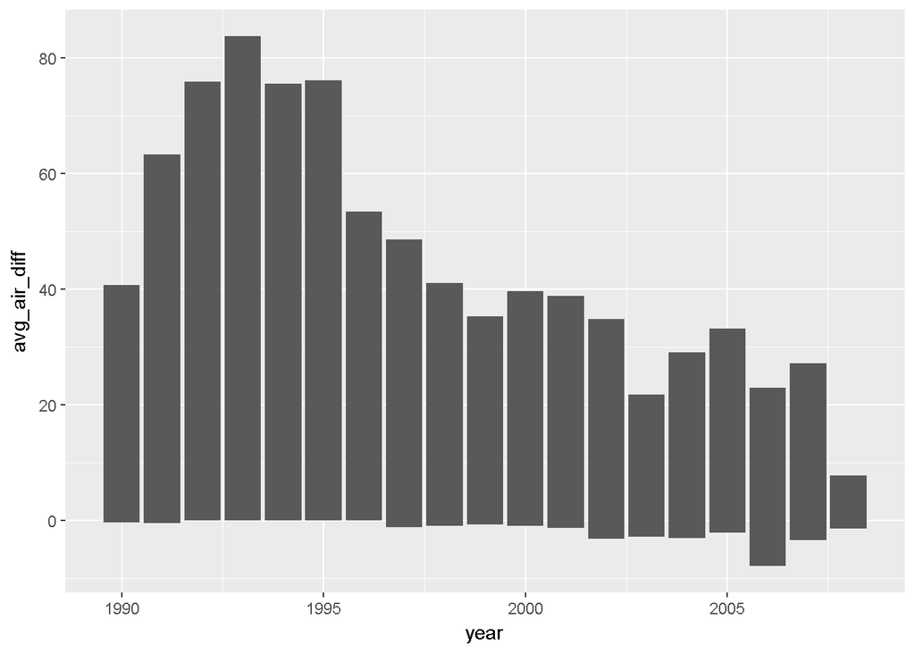

```r
library(ggplot2)

#generate a difference in max temp variable
sj_train_labels$avg_air_diff <- sj_train_labels$station_avg_temp_c - sj_train_labels$reanalysis_avg_temp_k

#barplot the difference by year
ggplot(sj_train_labels,aes(x=year, y=avg_air_diff))+
  geom_bar(stat='identity')
```

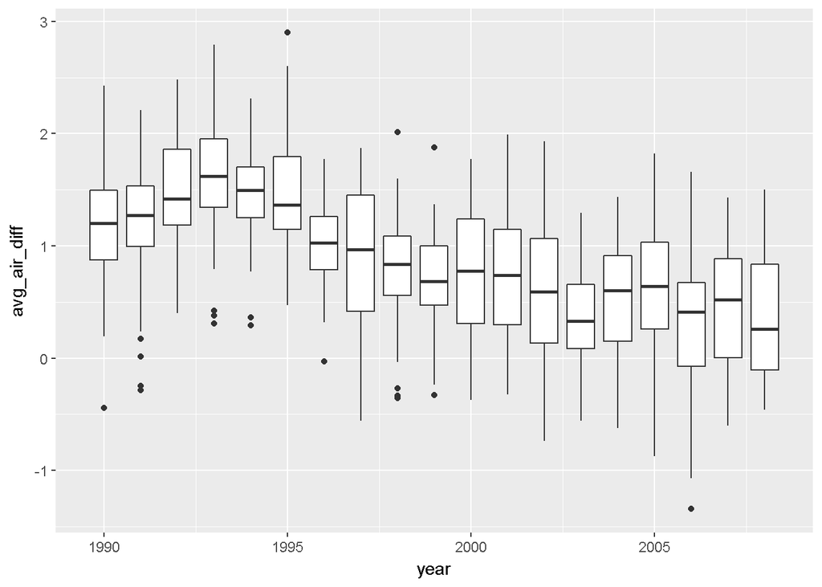

```r
#box plot difference by year
ggplot(sj_train_labels, aes(x=year, y = avg_air_diff, group = year)) +   geom_boxplot()
```

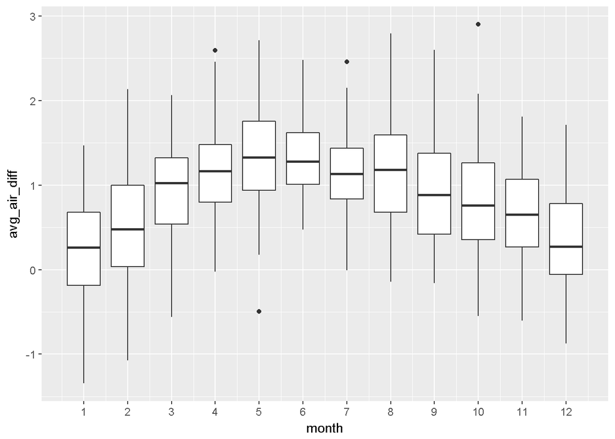

```r
#Add month to the dataframe
sj_train_labels$month <- as.POSIXlt(sj_train_labels$week_start_date)$mon +1

#box plot difference by month
ggplot(sj_train_labels, aes(x=month, y = avg_air_diff, group = month)) +   geom_boxplot() + scale_x_continuous(breaks=seq(1,12,1))
```

```r
sj_train_labels$avg_air_diff <- NULL
sj_train_labels$month <- NULL
```

### Difference in total precipitation

“station_precip_mm”, “precipitation_amt_mm”, “reanalysis_sat_precip_amt_mm”, “reanalysis_precip_amt_kg_per_m2”

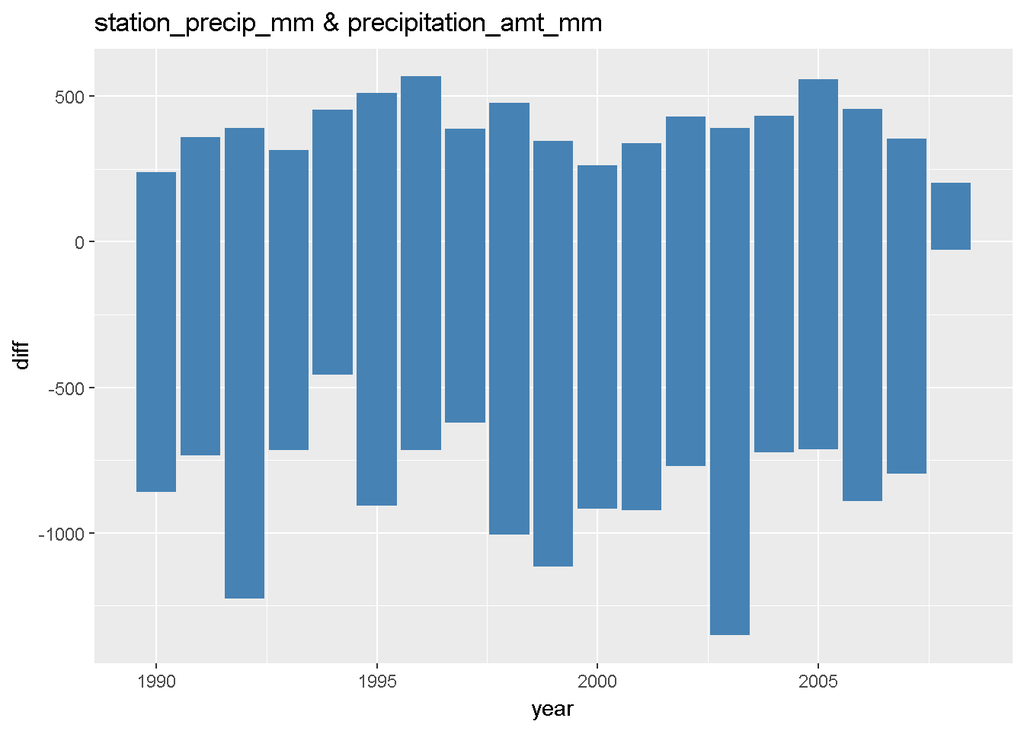

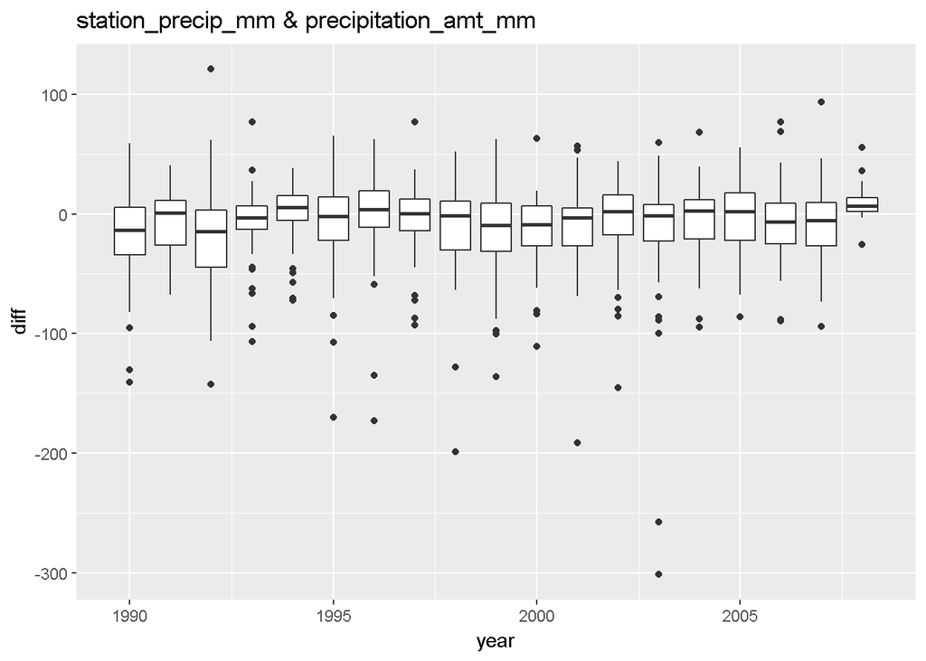

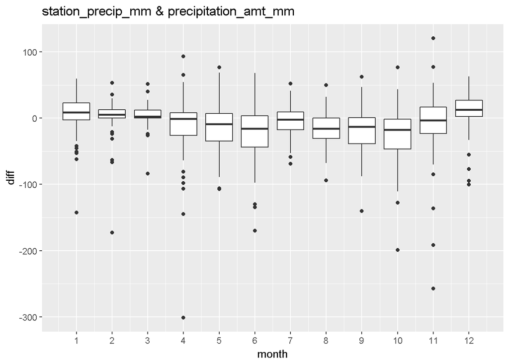

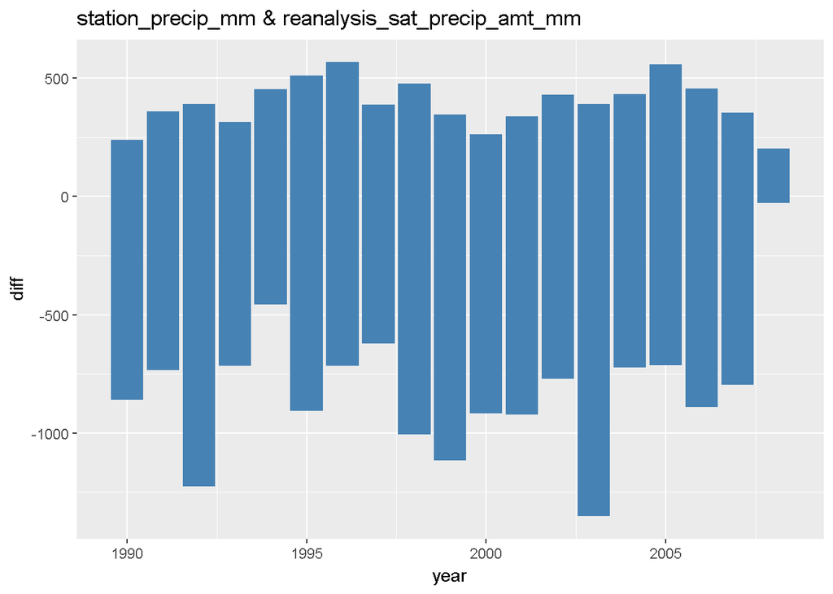

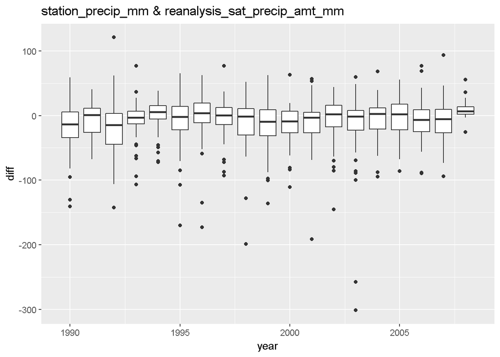

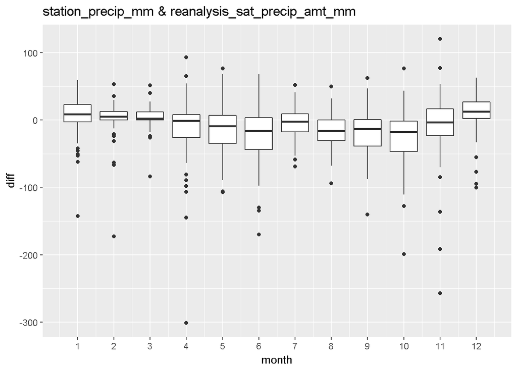

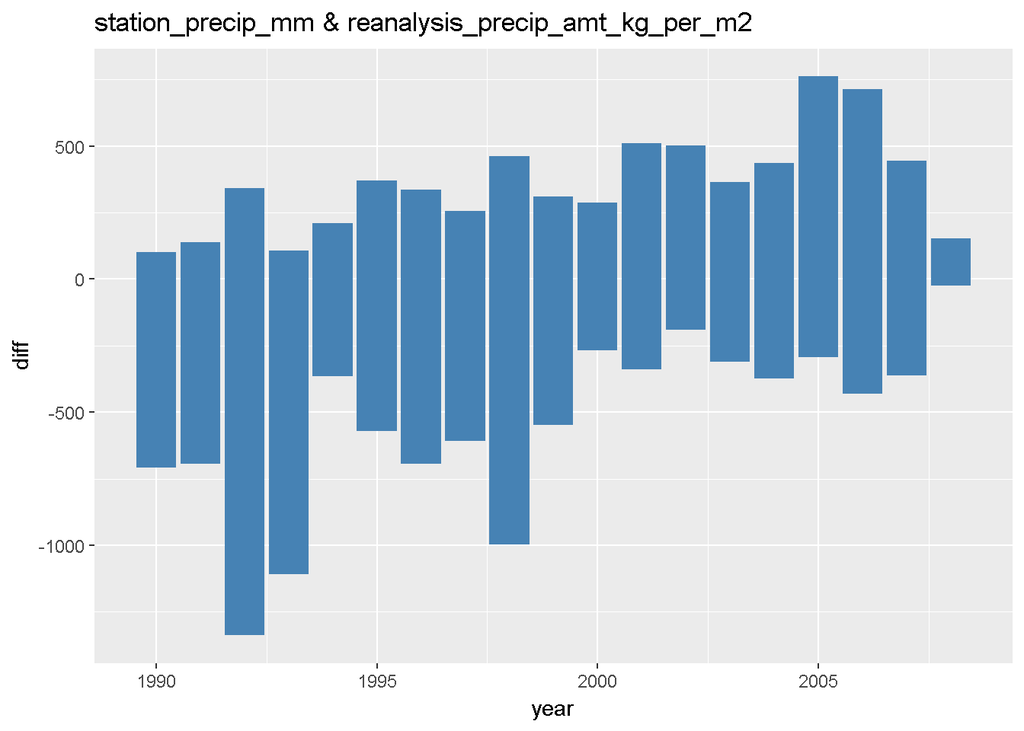

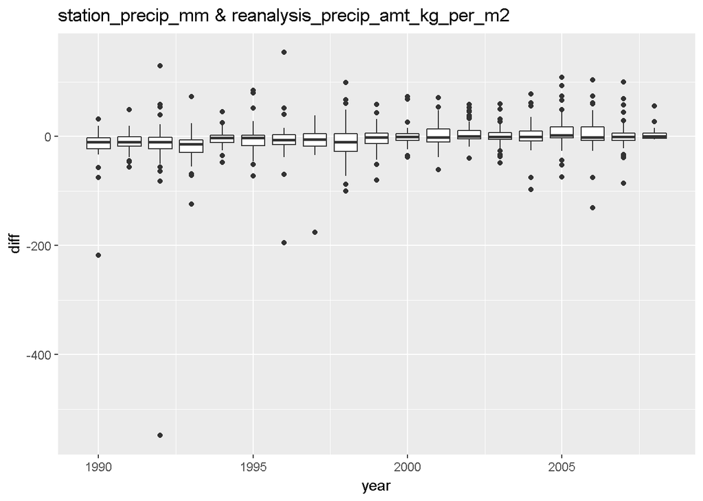

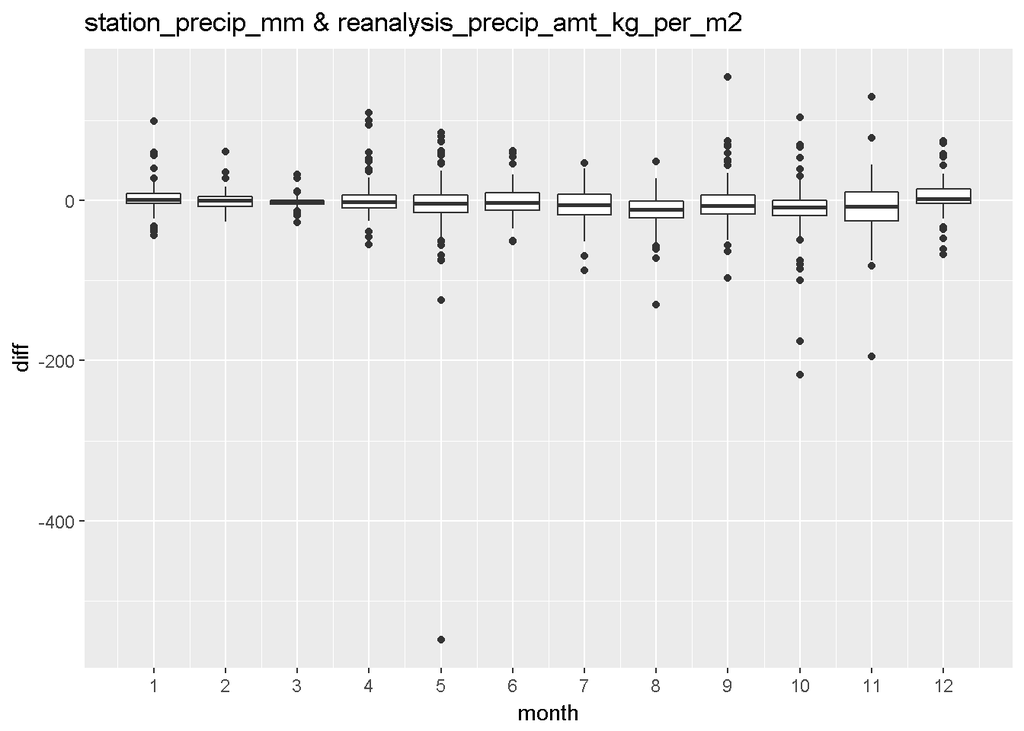

[figure not shown]

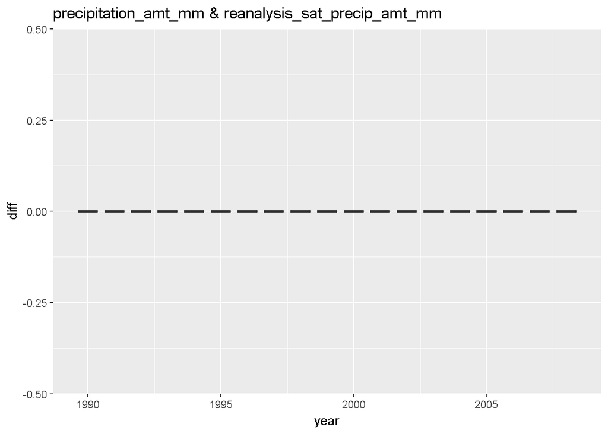

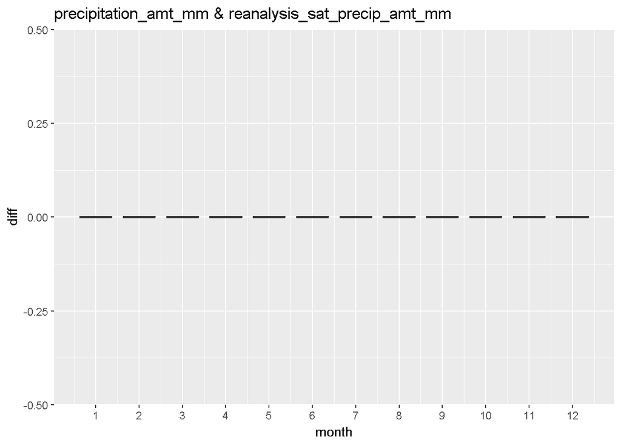

[6 more figures not shown]

```r
library(ggplot2)

precip <- c("station_precip_mm", "precipitation_amt_mm", "reanalysis_sat_precip_amt_mm", "reanalysis_precip_amt_kg_per_m2")

#Add month to the dataframe
sj_train_labels$month <- as.POSIXlt(sj_train_labels$week_start_date)$mon +1



for (i in 1:3){
  par(mfrow=c(1,3))
  #generate the first variable in the list
  p1 <- precip[i]
  ind1 <- which(colnames(sj_train_labels)==p1)
  for (j in ((i+1):4)){
    #generate the next variable in the list
    p2 <- precip[j]
  ind2 <- which(colnames(sj_train_labels)==p2)
  #generate a difference variable
   sj_train_labels$diff <- sj_train_labels[,ind1] - sj_train_labels[,ind2]

   #barplot the difference by year
   gg1 <-ggplot(sj_train_labels,
                 aes(x=year, y=diff))+
      geom_bar(stat = "identity", fill="steelblue") +
      ggtitle(paste(p1, "&", p2))
    print(gg1)

    #box plot the difference by year
   gg2 <-ggplot(sj_train_labels,
                 aes(x=year, y=diff, group = year)) +
      geom_boxplot() +
      ggtitle(paste(p1, "&", p2))
    print(gg2)

    #box plot difference by month
    gg3 <- ggplot(sj_train_labels,
                  aes(x=month, y = diff, group = month)) +
      geom_boxplot() +
      scale_x_continuous(breaks=seq(1,12,1)) +
      ggtitle(paste(p1, "&", p2))
    print(gg3)
  }
}
```

```r
sj_train_labels$diff <- NULL
sj_train_labels$month <- NULL
```

# ANALYSIS OF OUTLIERS

### GRAPH: Boxplot of climate variables (test and train)

Boxplot includes test and training set - NA still included

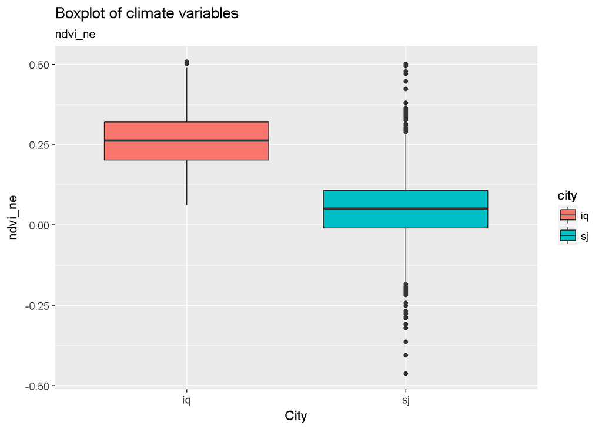

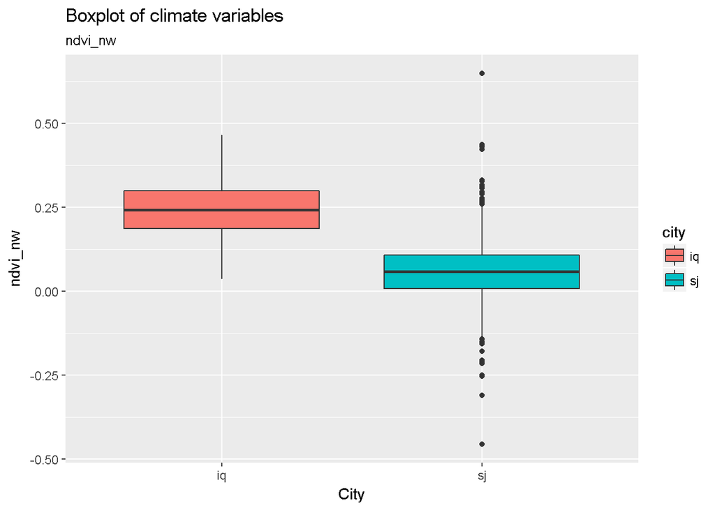

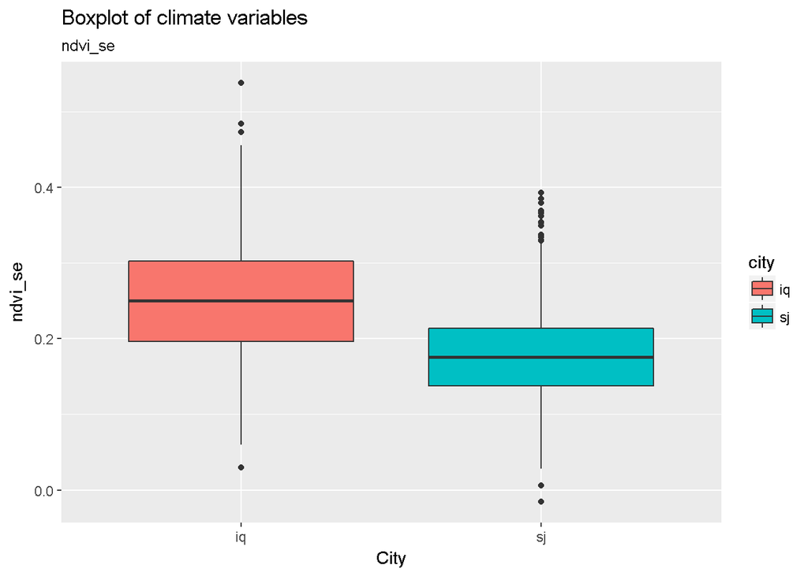

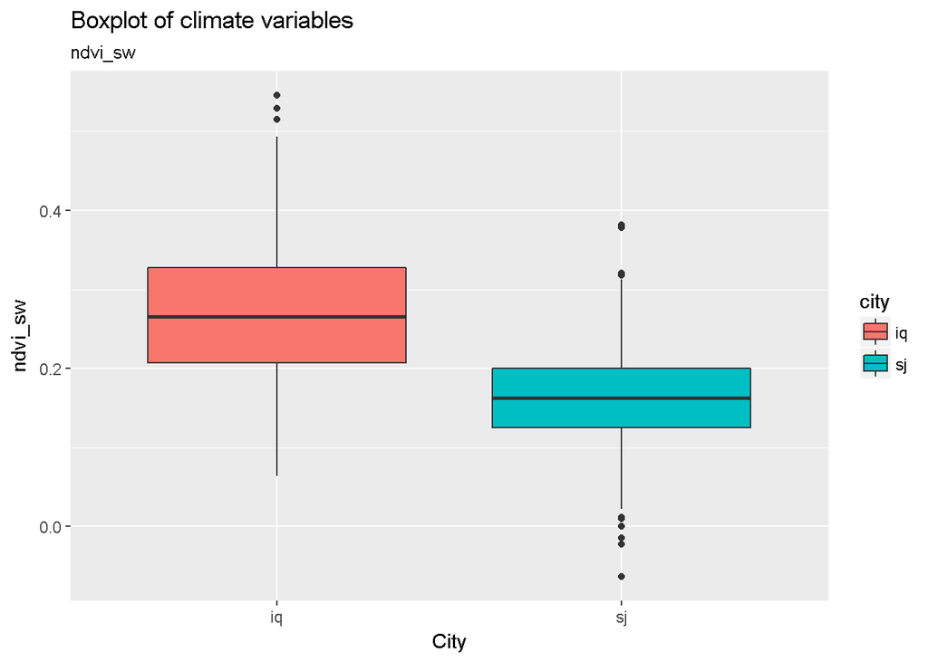

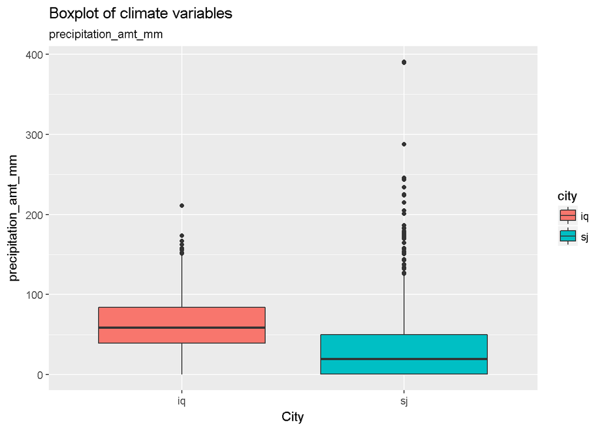

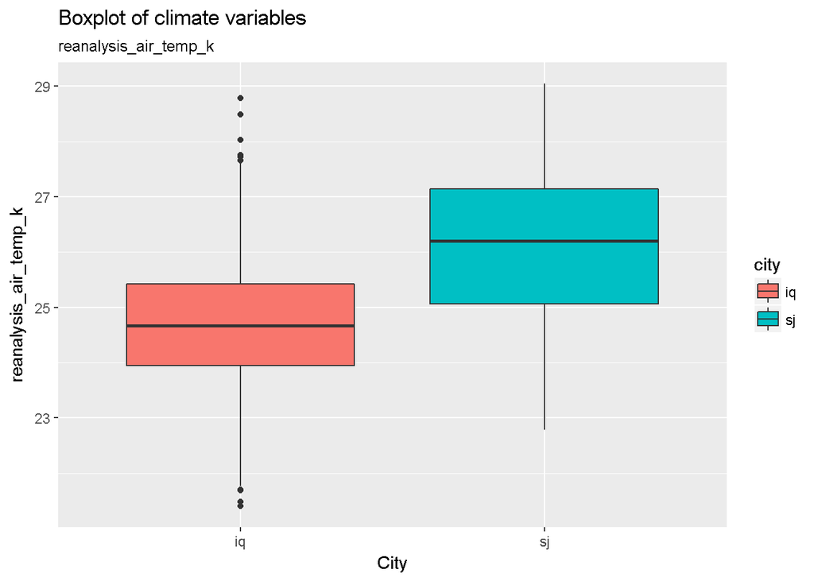

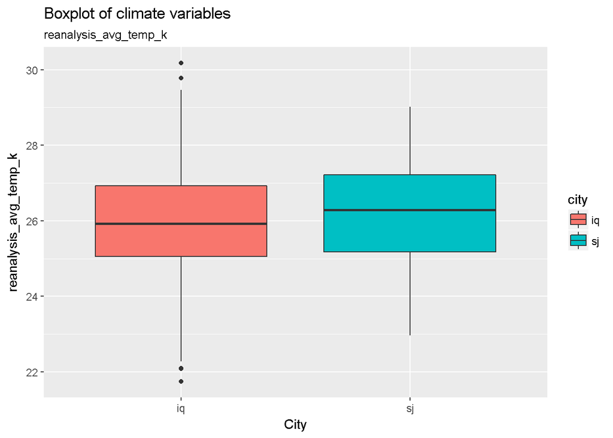

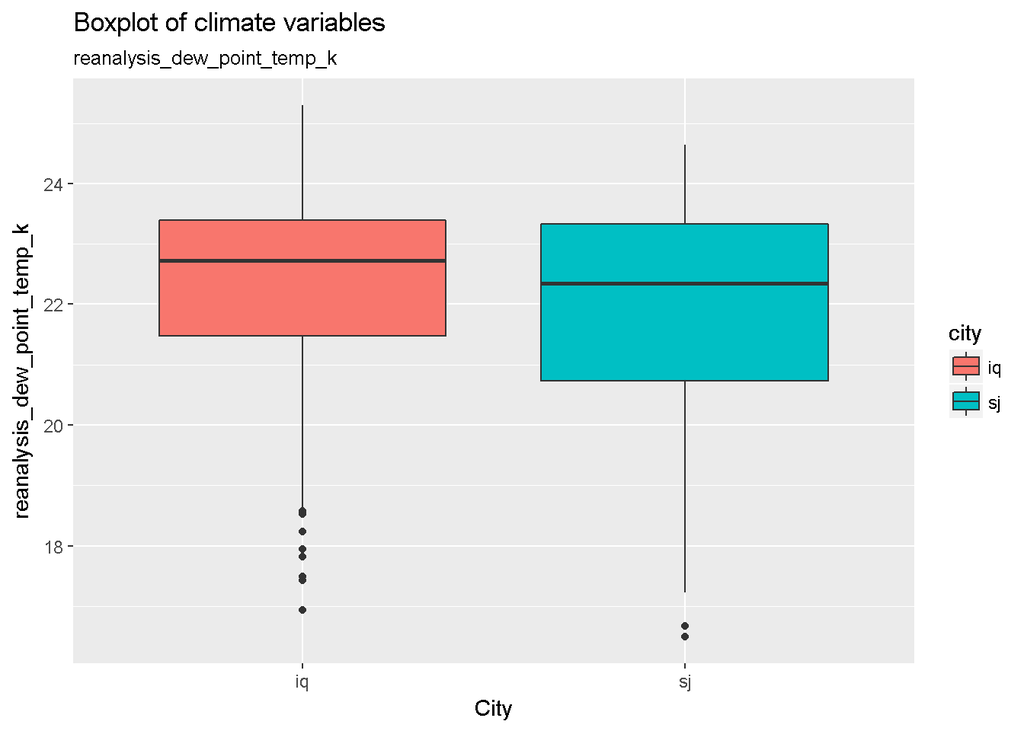

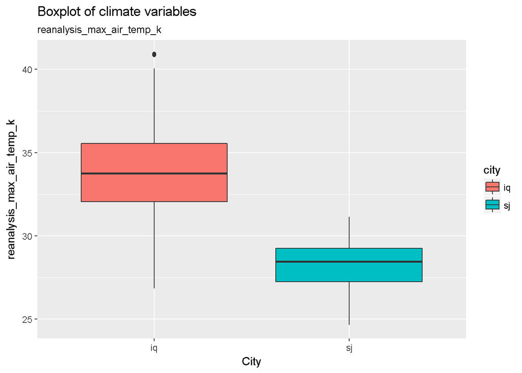

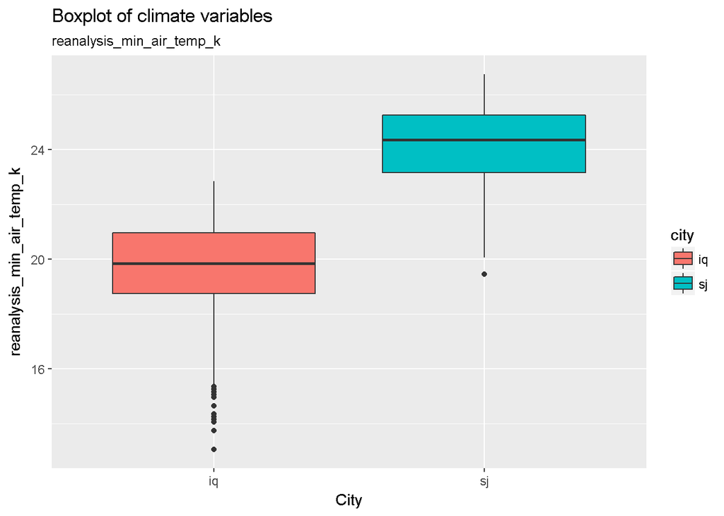

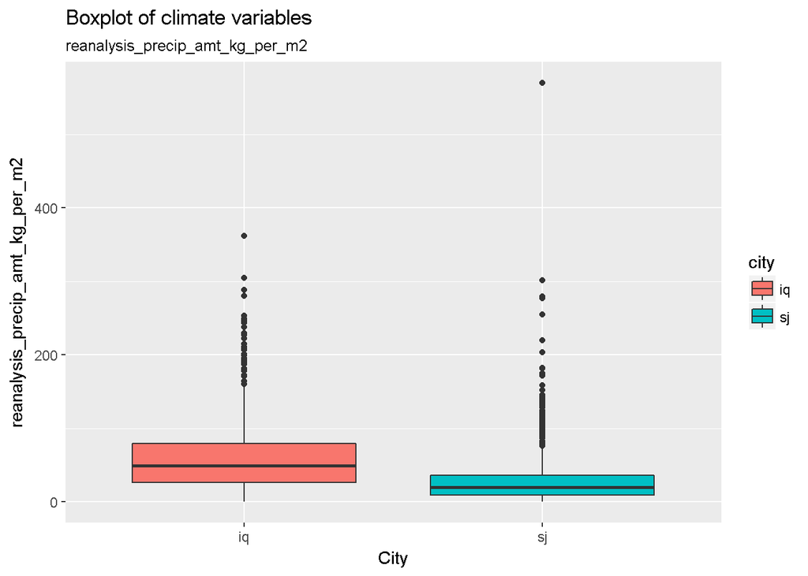

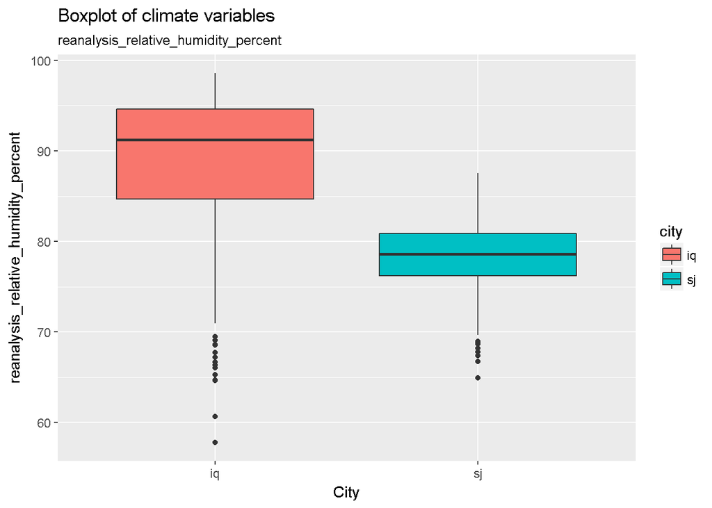

[8 more figures not shown]

```r
library(ggplot2)
cnames <- colnames(df)
for (i in 5:(ncol(df))) {
 p <- ggplot(df, aes(x=city, y = df[,i], fill = city)) +
  geom_boxplot() +
   labs(title = "Boxplot of climate variables",
       subtitle = cnames[i],
       x = "City", y = cnames[i])
 print(p)
}
```

```r
rm(p)
```

### GRAPH: Boxplot of total cases

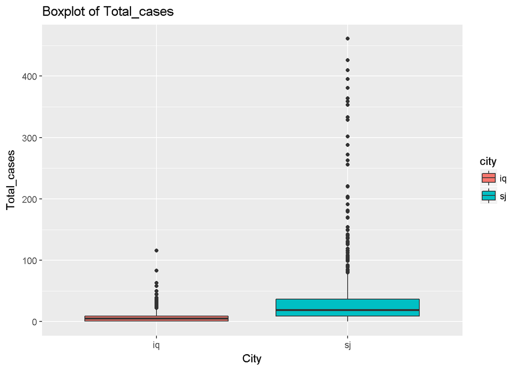

```r
library(ggplot2)
ggplot(df_train_labels, aes(x=city, y = total_cases, fill = city)) +
  geom_boxplot() +
   labs(title = "Boxplot of Total_cases",
       x = "City", y = "Total_cases")
```

# Check for missing values (is.na)

In this section, we look at the number of missing values. Later we will do something about these missing values.

```r
df.na <- sapply(df, function(x) sum(is.na (x)))

sj.na <- sapply(sj, function(x) sum(is.na (x)))
sj_train.na <- sapply(sj_train_labels, function(x) sum(is.na (x)))

iq.na <- sapply(iq, function(x) sum(is.na (x)))
iq_train.na <- sapply(iq_train_labels, function(x) sum(is.na (x)))

df_train_labels.na <- sum(is.na(df_train_labels$total_cases))
View(df.na)
View(sj.na)
View(iq.na)
View(sj_train.na)
View(iq_train.na)


df_train_labels.na
```

```
## [1] 0
```

```r
rm(df.na)
rm(sj.na)
rm(iq.na)
rm(sj_train.na)
rm(iq_train.na)
rm(df_train_labels.na)
```

## Missing values: Remove all rows with an NA in it

```r
sj_train_labels.naomit <- na.omit(sj_train_labels)
iq_train_labels.naomit <- na.omit(iq_train_labels)
```

## Missing values: Using last non-NA value and rbind the two city dataframes

```r
library(zoo)
#library(tidyverse)
library(plyr)
sj_train_labels <- sj_train_labels[order(sj_train_labels$year, sj_train_labels$weekofyear),]
iq_train_labels <- iq_train_labels[order(iq_train_labels$year, iq_train_labels$weekofyear),]

sj_train_labels.lastna <- sj_train_labels
iq_train_labels.lastna <-iq_train_labels

sj_train_labels.lastna <- colwise(na.locf)(sj_train_labels.lastna)
iq_train_labels.lastna <- colwise(na.locf)(iq_train_labels.lastna)

#Issues using tidyverse as the locf function converts all values to character
# sj_train_labels.lastna <- sj_train_labels.lastna %>% do(na.locf(.))
# iq_train_labels.lastna <-iq_train_labels.lastna %>% do(na.locf(.))

sum(is.na(sj_train_labels.lastna))
sum(is.na(iq_train_labels.lastna))
```

[output not shown]

# CORRELATION ANALYSIS

In this section, we look at the correlation between the total_cases and the climate variables.

First we need to remove any of the non-numeric variables. The missing values are still in this first correlation analysis but this will be repeated with the missing values included.

## Correlation analysls before missing values are addressed

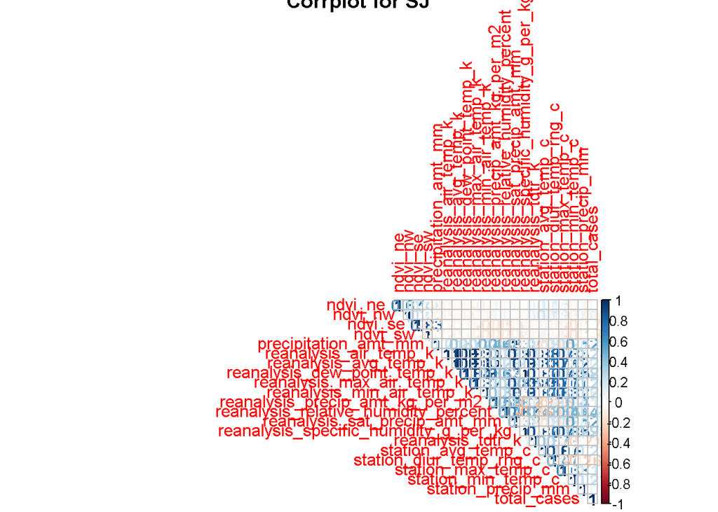

```r
library(corrplot)
#Correlation for SJ

sj_train_labels.cor <-data.frame(round(cor(sj_train_labels[,5:25],
                                           use = "complete.obs"),2))
View(sj_train_labels.cor)

corrplot(as.matrix(sj_train_labels.cor),
         method = "number",
         type = "upper",
         title = "Corrplot for SJ")
```

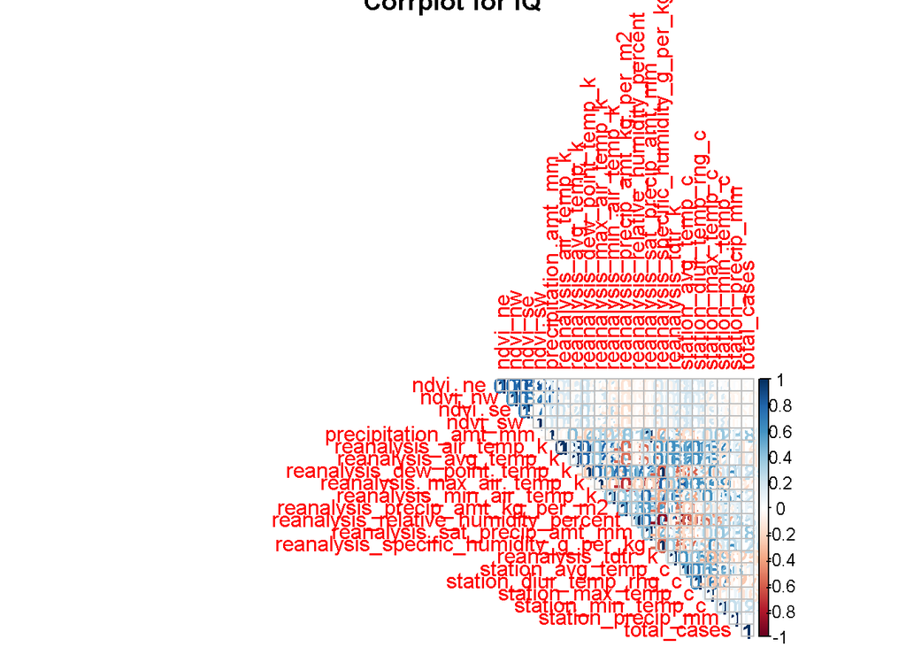

```r
#Correlation for IQ

iq_train_labels.cor <-data.frame(round(cor(iq_train_labels[,5:25],
                                           use = "complete.obs"),2))
View(iq_train_labels.cor)

corrplot(as.matrix(iq_train_labels.cor),
         method = "number",
         type = "upper",
         title = "Corrplot for IQ")
```

### Export correlation to CSV

```r
# write.csv(df_train_labels.cor, file = "df_train_labels.cor.csv")
# write.csv(sj_train_labels.cor, file = "sj_train_labels.cor.csv")
# write.csv(iq_train_labels.cor, file = "iq_train_labels.cor.csv")
```

## Comparison of correlations with the other non-na dataframes

### Correlation with na.omit

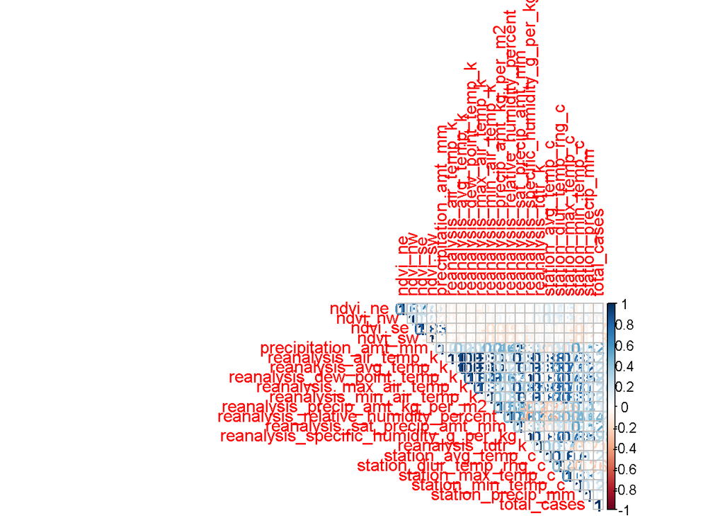

```r
library(corrplot)
sj_train_labels.cor.naomit <-data.frame(round(cor(sj_train_labels.naomit[,5:25],
                                           use = "complete.obs"),2))
#View(sj_train_labels.cor.naomit)

corrplot(as.matrix(sj_train_labels.cor.naomit),
         method = "number",
         type = "upper")
```

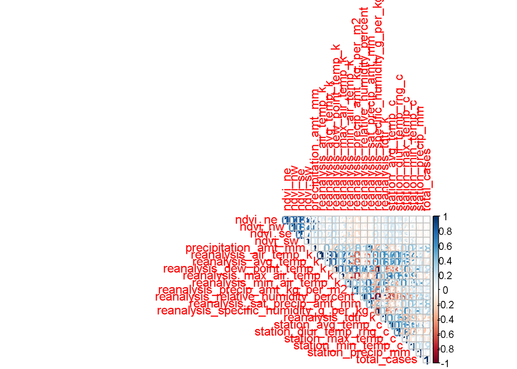

```r
iq_train_labels.cor.naomit <-data.frame(round(cor(iq_train_labels.naomit[,5:25],
                                           use = "complete.obs"),2))
#View(iq_train_labels.cor.naomit)

corrplot(as.matrix(iq_train_labels.cor.naomit),
         method = "number",
         type = "upper")
```

```r
rm(sj_train_labels.cor)
rm(iq_train_labels.cor)
```

### Correlation with Last NA

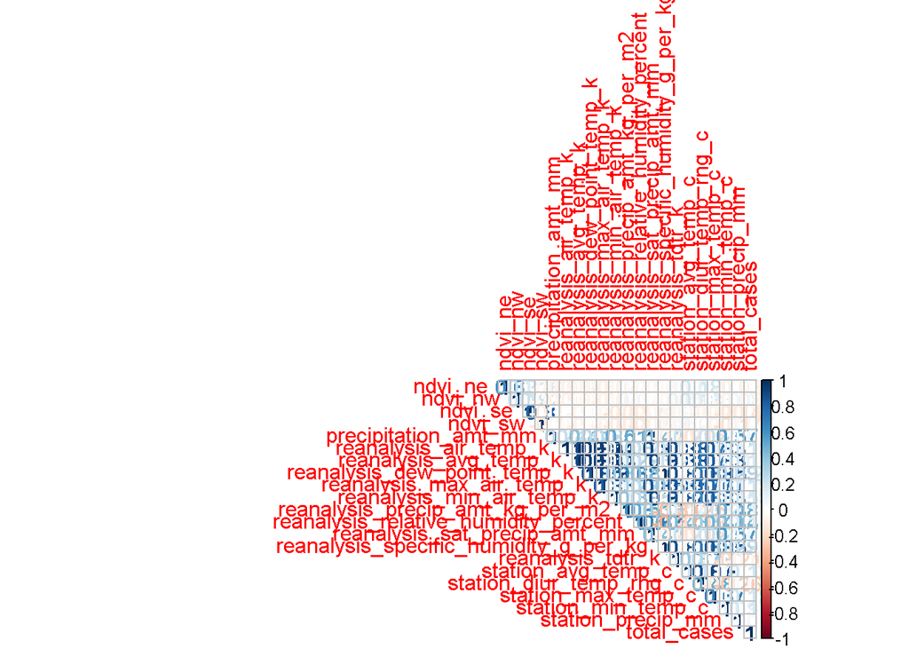

```r
library(corrplot)
sj_train_labels.cor.lastna <-data.frame(round(cor(sj_train_labels.lastna[,5:25],
                                           use = "complete.obs"),2))
#View(sj_train_labels.cor.lastna)

corrplot(as.matrix(sj_train_labels.cor.lastna),
         method = "number",
         type = "upper")
```

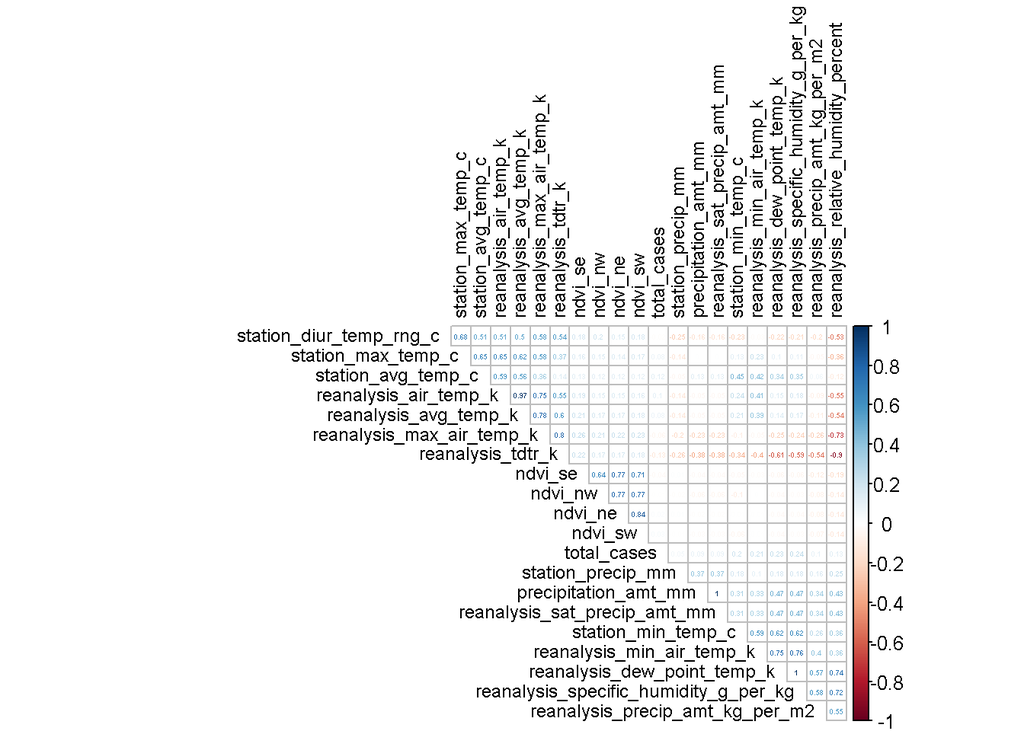

```r
iq_train_labels.cor.lastna <-data.frame(round(cor(iq_train_labels.lastna[,5:25],
                                           use = "complete.obs"),2))
#SView(iq_train_labels.cor.lastna)

corrplot(as.matrix(iq_train_labels.cor.lastna),
         type = "upper",
         tl.pos = "td",
         method = "number",
         tl.cex = 0.75,
         tl.col = 'black',
         order = "hclust",
         number.cex= 7/ncol(iq_train_labels.lastna),
         diag = FALSE)
```

### Export non-na correlation to CSV

```r
# write.csv(sj_train_labels.cor.naomit, file = "sj_train_labels.cor.naomit.csv")
# write.csv(iq_train_labels.cor.naomit, file = "iq_train_labels.cor.naomit.csv")
#

# write.csv(sj_train_labels.cor.lastna, file = "sj_train_labels.cor.lastna.csv")
# write.csv(iq_train_labels.cor.lastna, file = "iq_train_labels.cor.lastna.csv")
```

### Conclusion about correlation

# FEATURE SELECTION and DIMENTIONALITY REDUCTION

We will use various methods to see if we can find any features that need to be eliminated

## Feature selection via CaretR (Remove redundant features)

### CaretR (Remove redundant features) for SJ

```r
library(mlbench)
library(caret)
# calculate correlation matrix
CorrelationMatrix <- cor(sj_train_labels.lastna[,5:25])
# find attributes that are highly corrected (ideally >0.75)
highlyCorrelated <- findCorrelation(CorrelationMatrix, cutoff=0.75)
# print indexes of highly correlated attributes
print(highlyCorrelated)
```

```
## [1] 14  8 16  6  7  9 10  5  3
```

```r
cnames <- colnames(sj_train_labels[,5:25])
for (i in list(highlyCorrelated)){
  print(cnames[i])
}
```

```
## [1] "reanalysis_specific_humidity_g_per_kg"
## [2] "reanalysis_dew_point_temp_k"
## [3] "station_avg_temp_c"
## [4] "reanalysis_air_temp_k"
## [5] "reanalysis_avg_temp_k"
## [6] "reanalysis_max_air_temp_k"
## [7] "reanalysis_min_air_temp_k"
## [8] "precipitation_amt_mm"
## [9] "ndvi_se"
```

## Feature selection via CaretR (via RFE)

### CaretR (via RFE) for SJ

```r
library(mlbench)
library(caret)
# define the control using a random forest selection function
control <- rfeControl(functions=rfFuncs, method="cv", number=10)
# run the RFE algorithm for SJ
sj_rfe_results <- rfe(sj_train_labels.lastna[,5:24], sj_train_labels.lastna[,25], sizes=c(5:25), rfeControl=control)
# summarize the results
print(sj_rfe_results)
```

```
##
## Recursive feature selection
##
## Outer resampling method: Cross-Validated (10 fold)
##
## Resampling performance over subset size:
##
##  Variables  RMSE Rsquared   MAE RMSESD RsquaredSD MAESD Selected
##          5 37.08   0.4113 23.64  5.469     0.2491 2.851
##          6 37.61   0.3919 24.18  6.157     0.2399 3.778
##          7 36.57   0.4281 23.92  7.139     0.2164 3.970
##          8 36.67   0.4330 24.09  7.047     0.2138 3.852
##          9 36.16   0.4416 23.76  7.069     0.2162 3.826
##         10 36.13   0.4424 23.87  6.840     0.2161 3.783        *
##         11 37.04   0.4264 24.14  8.320     0.2064 3.990
##         12 36.87   0.4317 24.15  8.907     0.2064 4.309
##         13 37.23   0.4243 24.39  8.878     0.2072 4.340
##         14 37.41   0.4216 24.39  9.046     0.2082 4.346
##         15 37.08   0.4328 24.19  8.459     0.2047 4.048
##         16 37.62   0.4175 24.45  8.805     0.2031 4.133
##         17 37.75   0.4161 24.42  9.131     0.2071 4.138
##         18 37.39   0.4225 24.29  8.954     0.2037 3.973
##         19 37.74   0.4096 24.49  8.887     0.2046 3.889
##         20 38.16   0.4038 24.70  9.279     0.2072 3.989
##
## The top 5 variables (out of 10):
##    ndvi_se, ndvi_sw, ndvi_nw, reanalysis_specific_humidity_g_per_kg, reanalysis_relative_humidity_percent
```

```r
# list the chosen features
predictors(sj_rfe_results)
```

```
##  [1] "ndvi_se"
##  [2] "ndvi_sw"
##  [3] "ndvi_nw"
##  [4] "reanalysis_specific_humidity_g_per_kg"
##  [5] "reanalysis_relative_humidity_percent"
##  [6] "reanalysis_dew_point_temp_k"
##  [7] "reanalysis_min_air_temp_k"
##  [8] "ndvi_ne"
##  [9] "station_precip_mm"
## [10] "reanalysis_precip_amt_kg_per_m2"
```

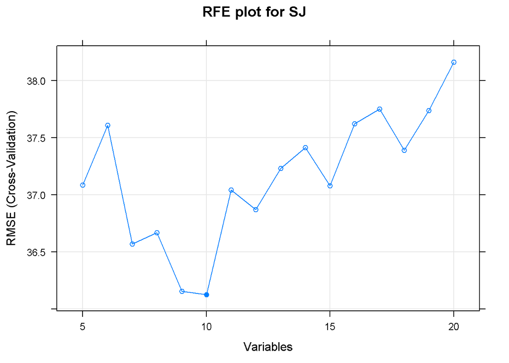

```r
# plot the results
plot(sj_rfe_results, type=c("g", "o"), main = "RFE plot for SJ")
```